# Practicum 1

Amey Arya (arya.am@northeastern.edu) Sai Sankar Gochhayat (gochhayat.s@northeastern.edu)

We completed the practicum working with a AWS hosted MySQL database.

```r
# 1. Library
library(RMySQL)

# 2. Settings
db_user <- 'saisankar'
db_password <- 'CS5200NEU'
db_name <- 'saidb'
db_host <- 'saidb.cyxbppiqnraw.us-east-1.rds.amazonaws.com' # AWS Host
db_port <- 3306

# 3. Read data from db
mydb <-  dbConnect(MySQL(), user = db_user, password = db_password,
                 db_name = db_name, host = db_host, port = db_port)
```

# ERD diagram attached

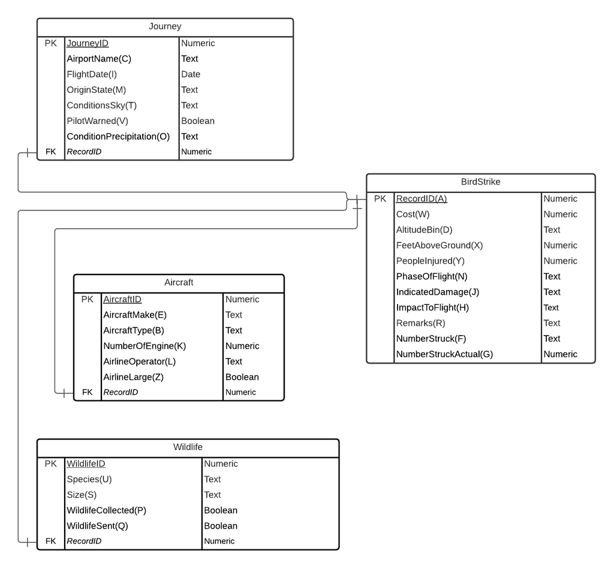

We have have segregated the data into 4 different tables which each represent the individual entities better. The foreign key in the child tables (recordID) binds all the data together. We initially thought of a different approach having many to many relationship that reduced the redundancy, but given the timeframe of the practicum we decided to go ahead with this 1:1 approach.

Using the relevant database before running other chunks.

```sql
USE saidb;
```

Note:- Each of the sections below deal with creation of the respective table and data population.

## BirdStrike Table

### Creating BirdStrike Table.

This follows the ERD diagram schema for BirdStrike, the recordID is the primary key here.

```sql
CREATE TABLE IF NOT EXISTS BirdStrike (
  RecordID INT NOT NULL,
  Cost INT NOT NULL DEFAULT 0,
  AltitudeBin VARCHAR(100) NOT NULL DEFAULT "< 1000 ft",
  FeetAboveGround INT NOT NULL DEFAULT 0,
  PeopleInjured INT NOT NULL DEFAULT 0,
  PhaseOfFlight VARCHAR(100),
  IndicatedDamage VARCHAR(100) NOT NULL DEFAULT "No damage",
  ImpactToFlight VARCHAR(100) DEFAULT "None",
  Remarks LONGTEXT,
  NumberStruck VARCHAR(100) NOT NULL DEFAULT "0",
  NumberStruckActual INT NOT NULL DEFAULT 0,
  PRIMARY KEY ( RecordID )
);
```

```sql
DESCRIBE saidb.BirdStrike;
```

| Field | Type | Null | Key | Default | Extra |
| --- | --- | --- | --- | --- | --- |
| RecordID | int | NO | PRI | NA |  |
| Cost | int | NO |  | 0 |  |
| AltitudeBin | varchar(100) | NO |  | < 1000 ft |  |
| FeetAboveGround | int | NO |  | 0 |  |
| PeopleInjured | int | NO |  | 0 |  |
| PhaseOfFlight | varchar(100) | YES |  | NA |  |
| IndicatedDamage | varchar(100) | NO |  | No damage |  |
| ImpactToFlight | varchar(100) | YES |  | None |  |
| Remarks | longtext | YES |  | NA |  |
| NumberStruck | varchar(100) | NO |  | 0 |  |

[output cut: 1 more lines]

```sql
DROP TABLE BirdStrike;
```

```sql
SELECT * FROM BirdStrike;
```

| RecordID | Cost | AltitudeBin | FeetAboveGround | PeopleInjured | PhaseOfFlight | IndicatedDamage | ImpactToFlight | Remarks | NumberStruck | NumberStruckActual |
| --- | --- | --- | --- | --- | --- | --- | --- | --- | --- | --- |
| 1195 | 0 | > 1000 ft | 2 | 0 | Approach | No damage | None | None. | 2 to 10 | 9 |
| 3019 | 0 | < 1000 ft | 400 | 0 | Climb | No damage | Precautionary Landing |  | 1 | 1 |
| 3500 | 0 | < 1000 ft | 1 | 0 | Approach | No damage | Precautionary Landing |  | 1 | 1 |
| 3504 | 0 | > 1000 ft | 1 | 0 | Approach | No damage | Precautionary Landing |  | 2 to 10 | 8 |
| 3597 | 0 | < 1000 ft | 200 | 0 | Approach | No damage | None |  | 1 | 1 |
| 4064 | 0 | < 1000 ft | 1 | 0 | Approach | No damage | None | A bird struck the left inboard flap and one was ingested into the #7 engine intake. | 2 to 10 | 10 |
| 4074 | 0 | < 1000 ft | 0 | 0 | Take-off run | No damage | None |  | 2 to 10 | 5 |
| 4076 | 0 | < 1000 ft | 500 | 0 | Climb | No damage | Precautionary Landing | During touch and go bird struck the top of the nose radome between the #! and #2 window. | 1 | 1 |
| 4090 | 0 | < 1000 ft | 50 | 0 | Climb | No damage | Precautionary Landing |  | 2 to 10 | 5 |
| 4091 | 0 | < 1000 ft | 0 | 0 | Take-off run | No damage | Aborted Take-off |  | 2 to 10 | 2 |

[output cut: 990 more lines]

Reading the CSV and creating a new df for BirdStrike that has been renamed according to the columns in the database.

```r
df <- read.csv(file = "BirdStrikesData.csv",
               header = T
              )
names(df)[1] <- "Record.ID"
head(df)
```

|  | Record.ID | Aircraft..Type | Airport..Name | Altitude.bin | Aircraft..Make.Model | Wildlife..Number.struck | Wildlife..Number.Struck.Actual | Effect..Impact.to.flight | FlightDate | Effect..Indicated.Damage | Aircraft..Number.of.engines. | Aircraft..Airline.Operator | Origin.State | When..Phase.of.flight | Conditions..Precipitation | Remains.of.wildlife.collected. | Remains.of.wildlife.sent.to.Smithsonian | Remarks | Wildlife..Size | Conditions..Sky | Wildlife..Species | Pilot.warned.of.birds.or.wildlife. | Cost..Total.. | Feet.above.ground | Number.of.people.injured | Is.Aircraft.Large. |
| --- | --- | --- | --- | --- | --- | --- | --- | --- | --- | --- | --- | --- | --- | --- | --- | --- | --- | --- | --- | --- | --- | --- | --- | --- | --- | --- |
| 1 | 202152 | Airplane | LAGUARDIA NY | > 1000 ft | B-737-400 | Over 100 | 859 | Engine Shut Down | 11/23/2000 0:00 | Caused damage | 2 | US AIRWAYS* | New York | Climb | None | FALSE | FALSE | FLT 753. PILOT REPTD A HUNDRED BIRDS ON UNKN TYPE. #1 ENG WAS SHUT DOWN AND DIVERTED TO EWR. SLIGHT VIBRATION. A/C WAS OUT OF SVC FOR REPAIRS TO COWLING, FAN DUCT ACCOUSTIC PANEL. INGESTION. DENTED FA… | Medium | No Cloud | Unknown bird - medium | N | 30,736 | 1,500 | 0 | Yes |
| 2 | 208159 | Airplane | DALLAS/FORT WORTH INTL ARPT | < 1000 ft | MD-80 | Over 100 | 424 | None | 7/25/2001 0:00 | Caused damage | 2 | AMERICAN AIRLINES | Texas | Landing Roll | None | FALSE | FALSE | 102 CARCASSES FOUND. 1 LDG LIGHT ON NOSE GEAR WAS DAMAGED AND REPLACED. | Small | Some Cloud | Rock pigeon | Y | 0 | 0 | 0 | No |
| 3 | 207601 | Airplane | LAKEFRONT AIRPORT | < 1000 ft | C-500 | Over 100 | 261 | None | 9/14/2001 0:00 | No damage | 2 | BUSINESS | Louisiana | Approach | None | FALSE | FALSE | FLEW UNDER A VERY LARGE FLOCK OF BIRDS OVER APCH END OF RWY. NO DMG. JUST A LOT OF BIRD DROPPINGS ON WINDSCREEN. | Small | No Cloud | European starling | N | 0 | 50 | 0 | No |
| 4 | 215953 | Airplane | SEATTLE-TACOMA INTL | < 1000 ft | B-737-400 | Over 100 | 806 | Precautionary Landing | 9/5/2002 0:00 | No damage | 2 | ALASKA AIRLINES | Washington | Climb | None | TRUE | FALSE | NOTAM WARNING. 26 BIRDS HIT THE A/C, FORCING AN EMERGENCY LDG. 77 BIRDS WERE FOUND DEAD ON RWY/TWY WITH GRASSHOPPERS IN THEIR STOMACHS. SAFETY AREAS COULD NOT BE THOROUGHLY INSPCTD DURING 14 MINUTE SH… | Small | Some Cloud | European starling | Y | 0 | 50 | 0 | Yes |
| 5 | 219878 | Airplane | NORFOLK INTL | < 1000 ft | CL-RJ100/200 | Over 100 | 942 | None | 6/23/2003 0:00 | No damage | 2 | COMAIR AIRLINES | Virginia | Approach | None | FALSE | FALSE | NO DMG REPTD. | Small | No Cloud | European starling | N | 0 | 50 | 0 | No |
| 6 | 218432 | Airplane | GUAYAQUIL/S BOLIVAR | < 1000 ft | A-300 | Over 100 | 537 | None | 7/24/2003 0:00 | No damage | 2 | AMERICAN AIRLINES | N/A | Take-off run | None | FALSE | FALSE | NO DMG. BIRD REMAINS ON F/O WINDSCREEN. | Small | No Cloud | Unknown bird - small | N | 0 | 0 | 0 | No |

```r
names(df)
```

```
 [1] "Record.ID"                               "Aircraft..Type"                          "Airport..Name"
 [4] "Altitude.bin"                            "Aircraft..Make.Model"                    "Wildlife..Number.struck"
 [7] "Wildlife..Number.Struck.Actual"          "Effect..Impact.to.flight"                "FlightDate"
[10] "Effect..Indicated.Damage"                "Aircraft..Number.of.engines."            "Aircraft..Airline.Operator"
[13] "Origin.State"                            "When..Phase.of.flight"                   "Conditions..Precipitation"
[16] "Remains.of.wildlife.collected."          "Remains.of.wildlife.sent.to.Smithsonian" "Remarks"
[19] "Wildlife..Size"                          "Conditions..Sky"                         "Wildlife..Species"
[22] "Pilot.warned.of.birds.or.wildlife."      "Cost..Total.."                           "Feet.above.ground"
[25] "Number.of.people.injured"                "Is.Aircraft.Large."
```

```r
birdstrike_df <- df[c("Record.ID",
                      "Cost..Total..",
                      "Altitude.bin",
                      "Feet.above.ground",
                      "Number.of.people.injured",
                      "When..Phase.of.flight",
                      "Effect..Indicated.Damage",
                      "Effect..Impact.to.flight",
                      "Remarks",
                      "Wildlife..Number.struck",
                      "Wildlife..Number.Struck.Actual"
                      )]
names(birdstrike_df)[1] <- "RecordID"
names(birdstrike_df)[2] <- "Cost"
names(birdstrike_df)[3] <- "AltitudeBin"
names(birdstrike_df)[4] <- "FeetAboveGround"
names(birdstrike_df)[5] <- "PeopleInjured"
names(birdstrike_df)[6] <- "PhaseOfFlight"
names(birdstrike_df)[7] <- "IndicatedDamage"
names(birdstrike_df)[8] <- "ImpactToFlight"
names(birdstrike_df)[9] <- "Remarks"
names(birdstrike_df)[10] <- "NumberStruck"
names(birdstrike_df)[11] <- "NumberStruckActual"
birdstrike_df
```

| RecordID | Cost | AltitudeBin | FeetAboveGround | PeopleInjured | PhaseOfFlight | IndicatedDamage | ImpactToFlight | Remarks | NumberStruck | NumberStruckActual |
| --- | --- | --- | --- | --- | --- | --- | --- | --- | --- | --- |
| 202152 | 30,736 | > 1000 ft | 1,500 | 0 | Climb | Caused damage | Engine Shut Down | FLT 753. PILOT REPTD A HUNDRED BIRDS ON UNKN TYPE. #1 ENG WAS SHUT DOWN AND DIVERTED TO EWR. SLIGHT VIBRATION. A/C WAS OUT OF SVC FOR REPAIRS TO COWLING, FAN DUCT ACCOUSTIC PANEL. INGESTION. DENTED FA… | Over 100 | 859 |
| 208159 | 0 | < 1000 ft | 0 | 0 | Landing Roll | Caused damage | None | 102 CARCASSES FOUND. 1 LDG LIGHT ON NOSE GEAR WAS DAMAGED AND REPLACED. | Over 100 | 424 |
| 207601 | 0 | < 1000 ft | 50 | 0 | Approach | No damage | None | FLEW UNDER A VERY LARGE FLOCK OF BIRDS OVER APCH END OF RWY. NO DMG. JUST A LOT OF BIRD DROPPINGS ON WINDSCREEN. | Over 100 | 261 |
| 215953 | 0 | < 1000 ft | 50 | 0 | Climb | No damage | Precautionary Landing | NOTAM WARNING. 26 BIRDS HIT THE A/C, FORCING AN EMERGENCY LDG. 77 BIRDS WERE FOUND DEAD ON RWY/TWY WITH GRASSHOPPERS IN THEIR STOMACHS. SAFETY AREAS COULD NOT BE THOROUGHLY INSPCTD DURING 14 MINUTE SH… | Over 100 | 806 |
| 219878 | 0 | < 1000 ft | 50 | 0 | Approach | No damage | None | NO DMG REPTD. | Over 100 | 942 |
| 218432 | 0 | < 1000 ft | 0 | 0 | Take-off run | No damage | None | NO DMG. BIRD REMAINS ON F/O WINDSCREEN. | Over 100 | 537 |
| 221697 | 1,481,711 | < 1000 ft | 150 | 0 | Climb | Caused damage | Other |  | Over 100 | 227 |
| 236635 | 1,483,141 | < 1000 ft | 100 | 0 | Approach | Caused damage | Other | WS ASSISTED IN CLEAN-UP OF 273 STARLINGS AND 1 BROWN-HEADED COWBIRD FROM RWY THRESHOLD. PHOTOS OF A/C TAKEN. BORESCOPED BOTH ENGS. FOUND DENTS AND NICKS IN STAGES 3-6. ALL WITHIN LIMITS. CLEANED RADOM… | Over 100 | 320 |
| 207369 | 0 | < 1000 ft | 0 | 0 | Take-off run | No damage | Aborted Take-off |  | 2 to 10 | 9 |
| 204371 | 0 | < 1000 ft | 0 | 0 | Landing Roll | No damage | None | FLT 057 | 2 to 10 | 4 |

[output cut: 990 more lines]

Here we add the data to the Table finally using dbWriteTable.

```r
dbWriteTable(mydb, "BirdStrike", birdstrike_df[1:nrow(birdstrike_df),], append = TRUE,row.names = FALSE)
```

```
[1] TRUE
```

## Journey Table

### Creating Journey Table.

Journey related attributes are segregated into this schema called the Journey table. We have added couple of default values that relates best to the given data.

```sql
CREATE TABLE IF NOT EXISTS Journey (
  JourneyID INT NOT NULL AUTO_INCREMENT,
  AirportName VARCHAR(100) NOT NULL,
  FlightDate DATE NOT NULL,
  OriginState VARCHAR(100) NOT NULL,
  ConditionsSky VARCHAR(100) NOT NULL DEFAULT "N/A",
  PilotWarned boolean NOT NULL DEFAULT 0,
  ConditionPrecipitation VARCHAR(100) NOT NULL DEFAULT "None",
  RecordID INT NOT NULL,
  PRIMARY KEY ( JourneyID ),
  FOREIGN KEY (RecordID) references BirdStrike(RecordID)
    ON DELETE CASCADE
    ON UPDATE CASCADE
);
```

```sql
DESCRIBE Journey;
```

| Field | Type | Null | Key | Default | Extra |
| --- | --- | --- | --- | --- | --- |
| JourneyID | int | NO | PRI | NA | auto_increment |
| AirportName | varchar(100) | NO |  | NA |  |
| FlightDate | date | NO |  | NA |  |
| OriginState | varchar(100) | NO |  | NA |  |
| ConditionsSky | varchar(100) | NO |  | N/A |  |
| PilotWarned | tinyint(1) | NO |  | 0 |  |
| ConditionPrecipitation | varchar(100) | NO |  | None |  |
| RecordID | int | NO | MUL | NA |  |

```sql
DROP TABLE Journey;
```

```sql
SELECT * FROM Journey;
```

| JourneyID | AirportName | FlightDate | OriginState | ConditionsSky | PilotWarned | ConditionPrecipitation | RecordID |
| --- | --- | --- | --- | --- | --- | --- | --- |
| 1 | LAGUARDIA NY | 2000-11-23 | New York | No Cloud | 0 | None | 202152 |
| 2 | DALLAS/FORT WORTH INTL ARPT | 2001-07-25 | Texas | Some Cloud | 0 | None | 208159 |
| 3 | LAKEFRONT AIRPORT | 2001-09-14 | Louisiana | No Cloud | 0 | None | 207601 |
| 4 | SEATTLE-TACOMA INTL | 2002-09-05 | Washington | Some Cloud | 0 | None | 215953 |
| 5 | NORFOLK INTL | 2003-06-23 | Virginia | No Cloud | 0 | None | 219878 |
| 6 | GUAYAQUIL/S BOLIVAR | 2003-07-24 | N/A | No Cloud | 0 | None | 218432 |
| 7 | NEW CASTLE COUNTY | 2003-08-17 | Delaware | No Cloud | 0 | None | 221697 |
| 8 | WASHINGTON DULLES INTL ARPT | 2006-03-01 | DC | Some Cloud | 0 | None | 236635 |
| 9 | ATLANTA INTL | 2000-01-06 | Georgia | Some Cloud | 0 | None | 207369 |
| 10 | ORLANDO SANFORD INTL AIRPORT | 2000-01-07 | Florida | Some Cloud | 0 | None | 204371 |

[output cut: 990 more lines]

Finally creating the journey df.

```r
journey_df <- df[c("Airport..Name",
                    "FlightDate",
                    "Origin.State",
                    "Conditions..Sky",
                    "Pilot.warned.of.birds.or.wildlife.",
                    "Conditions..Precipitation",
                    "Record.ID"
                  )]
names(journey_df)[1] <- "AirportName"
names(journey_df)[2] <- "FlightDate"
names(journey_df)[3] <- "OriginState"
names(journey_df)[4] <- "ConditionsSky"
names(journey_df)[5] <- "PilotWarned"
names(journey_df)[6] <- "ConditionPrecipitation"
names(journey_df)[7] <- "RecordID"
journey_df$JourneyID <- rownames(journey_df)
col_idx <- grep("JourneyID", names(journey_df))
journey_df <- journey_df[, c(col_idx, (1:ncol(journey_df))[-col_idx])]
journey_df$FlightDate <- strptime(as.character(journey_df$FlightDate), "%m/%d/%Y")
journey_df$FlightDate <- format(journey_df$FlightDate, "%Y-%m-%d")
journey_df
```

| JourneyID | AirportName | FlightDate | OriginState | ConditionsSky | PilotWarned | ConditionPrecipitation | RecordID |
| --- | --- | --- | --- | --- | --- | --- | --- |
| 1 | LAGUARDIA NY | 2000-11-23 | New York | No Cloud | N | None | 202152 |
| 2 | DALLAS/FORT WORTH INTL ARPT | 2001-07-25 | Texas | Some Cloud | Y | None | 208159 |
| 3 | LAKEFRONT AIRPORT | 2001-09-14 | Louisiana | No Cloud | N | None | 207601 |
| 4 | SEATTLE-TACOMA INTL | 2002-09-05 | Washington | Some Cloud | Y | None | 215953 |
| 5 | NORFOLK INTL | 2003-06-23 | Virginia | No Cloud | N | None | 219878 |
| 6 | GUAYAQUIL/S BOLIVAR | 2003-07-24 | N/A | No Cloud | N | None | 218432 |
| 7 | NEW CASTLE COUNTY | 2003-08-17 | Delaware | No Cloud | N | None | 221697 |
| 8 | WASHINGTON DULLES INTL ARPT | 2006-03-01 | DC | Some Cloud | Y | None | 236635 |
| 9 | ATLANTA INTL | 2000-01-06 | Georgia | Some Cloud | N | None | 207369 |
| 10 | ORLANDO SANFORD INTL AIRPORT | 2000-01-07 | Florida | Some Cloud | N | None | 204371 |

[output cut: 990 more lines]

And inserting into the database -

```r
dbWriteTable(mydb, "Journey", journey_df[1:nrow(journey_df),], append = TRUE,row.names = FALSE)
```

```
[1] TRUE
```

## Aircraft Table

### Creating Aircraft Table.

Aircraft related attributes are segregated into this schema called the Aircraft table. We have added couple of default values that relates best to the given data.

```sql
CREATE TABLE IF NOT EXISTS Aircraft (
  AircraftID INT NOT NULL AUTO_INCREMENT,
  AircraftMake VARCHAR(100) NOT NULL,
  AircraftType VARCHAR(100) NOT NULL DEFAULT "Airplane",
  NumberOfEngine INT,
  AirlineOperator VARCHAR(100),
  AirlineLarge boolean NOT NULL DEFAULT 0,
  RecordID INT NOT NULL,
  FOREIGN KEY (RecordID) references BirdStrike(RecordID)
    ON DELETE CASCADE
    ON UPDATE CASCADE,
  PRIMARY KEY ( AircraftID )
);
```

```sql
DESCRIBE Aircraft;
```

| Field | Type | Null | Key | Default | Extra |
| --- | --- | --- | --- | --- | --- |
| AircraftID | int | NO | PRI | NA | auto_increment |
| AircraftMake | varchar(100) | NO |  | NA |  |
| AircraftType | varchar(100) | NO |  | Airplane |  |
| NumberOfEngine | int | YES |  | NA |  |
| AirlineOperator | varchar(100) | YES |  | NA |  |
| AirlineLarge | tinyint(1) | NO |  | 0 |  |
| RecordID | int | NO | MUL | NA |  |

```sql
DROP TABLE Aircraft;
```

```sql
SELECT * FROM Aircraft;
```

| AircraftID | AircraftMake | AircraftType | NumberOfEngine | AirlineOperator | AirlineLarge | RecordID |
| --- | --- | --- | --- | --- | --- | --- |
| 1 | B-737-400 | Airplane | 2 | US AIRWAYS* | 1 | 202152 |
| 2 | MD-80 | Airplane | 2 | AMERICAN AIRLINES | 0 | 208159 |
| 3 | C-500 | Airplane | 2 | BUSINESS | 0 | 207601 |
| 4 | B-737-400 | Airplane | 2 | ALASKA AIRLINES | 1 | 215953 |
| 5 | CL-RJ100/200 | Airplane | 2 | COMAIR AIRLINES | 0 | 219878 |
| 6 | A-300 | Airplane | 2 | AMERICAN AIRLINES | 0 | 218432 |
| 7 | LEARJET-25 | Airplane | 2 | BUSINESS | 0 | 221697 |
| 8 | A-320 | Airplane | 2 | UNITED AIRLINES | 0 | 236635 |
| 9 | DC-9-30 | Airplane | 2 | AIRTRAN AIRWAYS | 0 | 207369 |
| 10 | A-330 | Airplane | 2 | AIRTOURS INTL | 0 | 204371 |

[output cut: 990 more lines]

```r
aircraft_df <- df[c("Aircraft..Make.Model",
                    "Aircraft..Type",
                    "Aircraft..Number.of.engines.",
                    "Aircraft..Airline.Operator",
                    "Is.Aircraft.Large.",
                    "Record.ID")]
names(aircraft_df)[1] <- "AircraftMake"
names(aircraft_df)[2] <- "AircraftType"
names(aircraft_df)[3] <- "NumberOfEngine"
names(aircraft_df)[4] <- "AirlineOperator"
names(aircraft_df)[5] <- "AirlineLarge"
names(aircraft_df)[6] <- "RecordID"
aircraft_df$AirlineLarge <- as.integer(aircraft_df$AirlineLarge == "Yes")
aircraft_df$AircraftID <- rownames(aircraft_df)
col_idx <- grep("AircraftID", names(aircraft_df))
aircraft_df <- aircraft_df[, c(col_idx, (1:ncol(aircraft_df))[-col_idx])]
aircraft_df
```

| AircraftID | AircraftMake | AircraftType | NumberOfEngine | AirlineOperator | AirlineLarge | RecordID |
| --- | --- | --- | --- | --- | --- | --- |
| 1 | B-737-400 | Airplane | 2 | US AIRWAYS* | 1 | 202152 |
| 2 | MD-80 | Airplane | 2 | AMERICAN AIRLINES | 0 | 208159 |
| 3 | C-500 | Airplane | 2 | BUSINESS | 0 | 207601 |
| 4 | B-737-400 | Airplane | 2 | ALASKA AIRLINES | 1 | 215953 |
| 5 | CL-RJ100/200 | Airplane | 2 | COMAIR AIRLINES | 0 | 219878 |
| 6 | A-300 | Airplane | 2 | AMERICAN AIRLINES | 0 | 218432 |
| 7 | LEARJET-25 | Airplane | 2 | BUSINESS | 0 | 221697 |
| 8 | A-320 | Airplane | 2 | UNITED AIRLINES | 0 | 236635 |
| 9 | DC-9-30 | Airplane | 2 | AIRTRAN AIRWAYS | 0 | 207369 |
| 10 | A-330 | Airplane | 2 | AIRTOURS INTL | 0 | 204371 |

[output cut: 990 more lines]

Finally writing the data into the table -

```r
dbWriteTable(mydb, "Aircraft", aircraft_df[1:nrow(aircraft_df),], append = TRUE,row.names = FALSE)
```

```
[1] TRUE
```

## Wildlife Table

### Creating Wildlife Table.

Wildlife related attributes are segregated into this schema called the Wildlife table. We have added couple of default values that relates best to the given data.

```sql
CREATE Table IF NOT EXISTS Wildlife (
  WildLifeID INT NOT NULL AUTO_INCREMENT,
  Species VARCHAR(100) NOT NULL,
  Size VARCHAR(100) NOT NULL DEFAULT "N/A",
  WildlifeCollected BOOLEAN NOT NULL DEFAULT 0,
  WildlifeSent BOOLEAN NOT NULL DEFAULT 0,
  CHECK (Size IN ('Small','Medium','Large','N/A')),
  RecordID INT NOT NULL,
  FOREIGN KEY (RecordID) references BirdStrike(RecordID)
    ON DELETE CASCADE
    ON UPDATE CASCADE,
  PRIMARY KEY ( WildLifeID )
)
```

```sql
DESCRIBE Wildlife;
```

| Field | Type | Null | Key | Default | Extra |
| --- | --- | --- | --- | --- | --- |
| WildLifeID | int | NO | PRI | NA | auto_increment |
| Species | varchar(100) | NO |  | NA |  |
| Size | varchar(100) | NO |  | N/A |  |
| WildlifeCollected | tinyint(1) | NO |  | 0 |  |
| WildlifeSent | tinyint(1) | NO |  | 0 |  |
| RecordID | int | NO | MUL | NA |  |

```sql
DROP TABLE Wildlife;
```

```sql
SELECT * FROM Wildlife;
```

| WildLifeID | Species | Size | WildlifeCollected | WildlifeSent | RecordID |
| --- | --- | --- | --- | --- | --- |
| 1 | Unknown bird - medium | Medium | 0 | 0 | 202152 |
| 2 | Rock pigeon | Small | 0 | 0 | 208159 |
| 3 | European starling | Small | 0 | 0 | 207601 |
| 4 | European starling | Small | 1 | 0 | 215953 |
| 5 | European starling | Small | 0 | 0 | 219878 |
| 6 | Unknown bird - small | Small | 0 | 0 | 218432 |
| 7 | European starling | Small | 1 | 1 | 221697 |
| 8 | European starling | Small | 1 | 0 | 236635 |
| 9 | Rock pigeon | Small | 0 | 0 | 207369 |
| 10 | Unknown bird - small | Small | 0 | 0 | 204371 |

[output cut: 990 more lines]

```r
wildlife_df <- df[c("Wildlife..Species",
                    "Wildlife..Size",
                    "Remains.of.wildlife.collected.",
                    "Remains.of.wildlife.sent.to.Smithsonian",
                    "Record.ID"
                    )]
names(wildlife_df)[1] <- "Species"
names(wildlife_df)[2] <- "Size"
names(wildlife_df)[3] <- "WildlifeCollected"
names(wildlife_df)[4] <- "WildlifeSent"
names(wildlife_df)[5] <- "RecordID"
wildlife_df$WildlifeCollected <- as.integer(wildlife_df$WildlifeCollected == "TRUE")
wildlife_df$WildlifeSent <- as.integer(wildlife_df$WildlifeSent == "TRUE")
wildlife_df$Size= replace(wildlife_df$Size, wildlife_df$Size == "", paste0("N/A"))
wildlife_df$WildLifeID <- rownames(wildlife_df)
col_idx <- grep("WildLifeID", names(wildlife_df))
wildlife_df <- wildlife_df[, c(col_idx, (1:ncol(wildlife_df))[-col_idx])]
wildlife_df
```

| WildLifeID | Species | Size | WildlifeCollected | WildlifeSent | RecordID |
| --- | --- | --- | --- | --- | --- |
| 1 | Unknown bird - medium | Medium | 0 | 0 | 202152 |
| 2 | Rock pigeon | Small | 0 | 0 | 208159 |
| 3 | European starling | Small | 0 | 0 | 207601 |
| 4 | European starling | Small | 1 | 0 | 215953 |
| 5 | European starling | Small | 0 | 0 | 219878 |
| 6 | Unknown bird - small | Small | 0 | 0 | 218432 |
| 7 | European starling | Small | 1 | 1 | 221697 |
| 8 | European starling | Small | 1 | 0 | 236635 |
| 9 | Rock pigeon | Small | 0 | 0 | 207369 |
| 10 | Unknown bird - small | Small | 0 | 0 | 204371 |

[output cut: 990 more lines]

Writing wildlife related data into the table from the df -

```r
dbWriteTable(mydb, "Wildlife", wildlife_df[1:nrow(wildlife_df),], append = TRUE,row.names = FALSE)
```

```
[1] TRUE
```

### Q4

Create a SQL query against your database to find the number of bird strike incidents for each airport upon take-off or climb. Include all airlines. You may either use a {sql} code chunk or an R function to execute the query.

```sql
-- Q4
SELECT AirportName, count(*) from BirdStrike
JOIN Journey ON Journey.recordID = BirdStrike.recordID
JOIN Aircraft on Aircraft.recordID = BirdStrike.recordID
WHERE BirdStrike.PhaseOfFlight IN ("Take-off run", "Climb")
GROUP BY AirportName;
```

| AirportName | count(*) |
| --- | --- |
| EDWARDS AIR FORCE BASE | 1 |
| EGLIN AFB/NW FLORIDA REGIONAL ARPT | 5 |
| BARKSDALE AIR FORCE BASE ARPT | 17 |
| CHARLESTON AFB/INTL ARPT | 24 |
| SHEPPARD AIR FORCE BASE | 16 |
| NORFOLK REGIONAL ARPT | 1 |
| SAN FRANCISCO INTL ARPT | 76 |
| ROSWELL INTL AIR CENTER | 3 |
| INDIANAPOLIS INTL | 64 |
| MINNEAPOLIS-ST PAUL INTL | 75 |

[output cut: 794 more lines]

### Q5

Create a SQL query against your database to find the airports that had the most bird strike incidents (during any flight phase). Include all airlines. You may either use a {sql} code chunk or an R function to execute the query.

```sql
-- Q5
SELECT AName as AirportName FROM
(
    SELECT AirportName as AName, count(*) as ACount, RANK () OVER (ORDER BY count(*) DESC) ARank
  FROM BirdStrike
    JOIN Journey ON Journey.recordID = BirdStrike.recordID
    JOIN Aircraft on Aircraft.recordID = BirdStrike.recordID
    GROUP BY AirportName
) as T
WHERE ARank = 1;
```

| AirportName |
| --- |
| DALLAS/FORT WORTH INTL ARPT |

### Q6

Create a SQL query against your database to find the number of bird strike incidents by year. Include all airlines. You may either use a {sql} code chunk or an R function to execute the query.

```sql
-- Q6
SELECT YEAR(FlightDate) as Year, count(*) as Count
FROM BirdStrike
JOIN Journey ON Journey.recordID = BirdStrike.recordID
JOIN Aircraft on Aircraft.recordID = BirdStrike.recordID
WHERE YEAR(FlightDate) != 0
GROUP BY YEAR(FlightDate)
ORDER BY YEAR(FlightDate);
```

| Year | Count |
| --- | --- |
| 2000 | 1367 |
| 2001 | 1230 |
| 2002 | 1681 |
| 2003 | 1568 |
| 2004 | 1692 |
| 2005 | 1853 |
| 2006 | 2159 |
| 2007 | 2301 |
| 2008 | 2258 |
| 2009 | 3247 |

[output cut: 2 more lines]

### Q7

Using the above data, build a line graph that visualizes the number of bird strikes incidents per year from 2000 to 2011. Adorn the graph with appropriate axis labels.

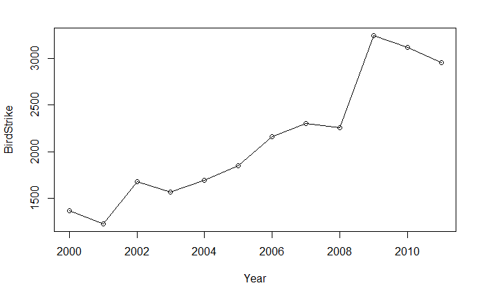

```r
# Q7
sql = "SELECT YEAR(FlightDate) as Year, count(*) as Count FROM BirdStrike
      JOIN Journey ON Journey.recordID = BirdStrike.recordID
      JOIN Aircraft on Aircraft.recordID = BirdStrike.recordID
      WHERE YEAR(FlightDate) != 0
      GROUP BY YEAR(FlightDate)
      ORDER BY YEAR(FlightDate)"
query <- dbSendQuery(mydb, sql)
dfplot <- fetch(query)
plot(x = dfplot$Year, y = dfplot$Count, xlab="Year", ylab="BirdStrike",type = "o")
```

### Q8

Create a stored procedure in MySQL (note that if you used SQLite, then you cannot complete this step) that adds a new bird strike incident to the database. You only need to include the following data: airport name, aircraft type, flight date, airline, flight phase. The remaining columns can be set with default values as defined by the table definitions. Show that the insertion worked as expected by retrieving and displaying the inserted data. Add any additional arguments to the stored procedure as needed.

We have added new mandatory parameters that are critical for the data model described above. And the remaining values are defaulted to the table defaults for simplicity purposes.

```sql
-- Q8
CREATE PROCEDURE InsertNewRecord(IN RecordID int,
IN AirportName varchar(100),
IN AircraftType varchar(100),
IN FlightDate date,
IN AirlineOperator varchar(100),
IN FlightPhase varchar(100),
IN OriginState varchar(100),
IN AircraftMake varchar(100),
IN Species varchar(100))
BEGIN
  INSERT into BirdStrike(RecordID,PhaseOfFlight) values(RecordID,FlightPhase);
  INSERT into Journey(AirportName,FlightDate,OriginState,RecordID) values(AirportName,FlightDate,OriginState,RecordID);
  INSERT into Aircraft(AircraftType,AirlineOperator,RecordID) values(AircraftType,AirlineOperator,RecordID);
  INSERT into Wildlife(Species,RecordID) values(Species,RecordID);
END
```

Calling the function to insert data.

```sql
CALL InsertNewRecord(45634325,'Logan Airport','Airplane','2021-03-03','United','Climb','MA','Boeing 777','Chicken');
```

Verifying that the stored proc works -

```sql
SELECT * FROM Aircraft WHERE RecordID = 45634325;
```

| AircraftID | AircraftMake | AircraftType | NumberOfEngine | AirlineOperator | AirlineLarge | RecordID |
| --- | --- | --- | --- | --- | --- | --- |
| 25559 |  | Airplane | NA | United | 0 | 45634325 |

```sql
DROP PROCEDURE IF EXISTS InsertNewRecord;
```

```r
dbDisconnect(mydb)
```